# lab4

Harley Combest

2023-07-28

## Task 1

```r
getwd()
```

```
## [1] "E:/main/Post 06282023/Classes/Applied Statistical Methods MATH4753/lab4"
```

## Task 2

```r
spruce.df=read.csv("SPRUCE.csv")
tail(spruce.df)
```

```
##    BHDiameter Height
## 31       17.7   19.9
## 32       20.7   19.4
## 33       21.0   20.4
## 34       13.3   15.5
## 35       15.9   17.6
## 36       22.9   19.2
```

## Task 3

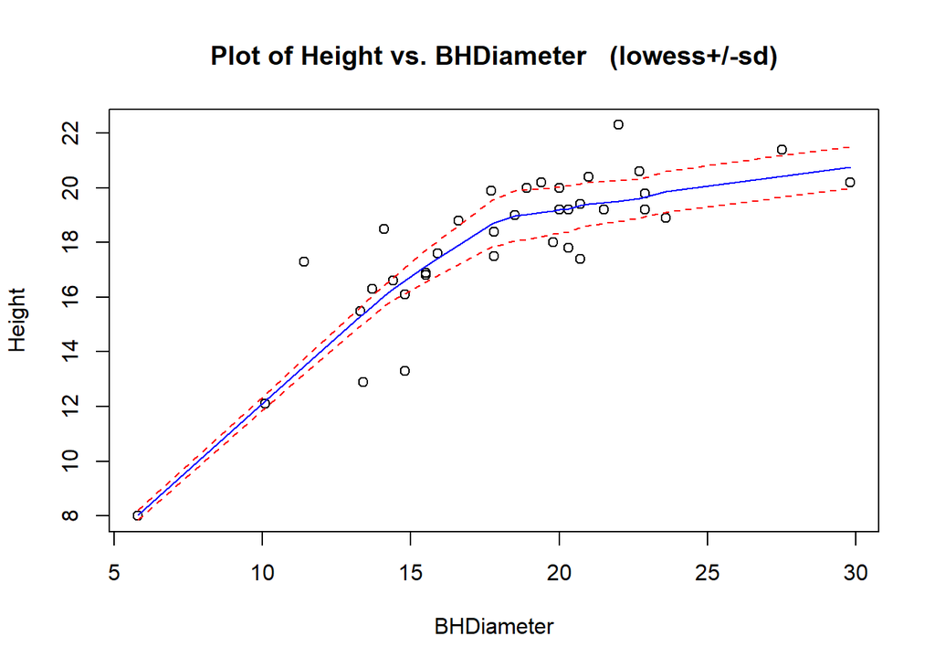

```r
#load s20x library and make lowess smoother
library(s20x)

trendscatter(Height~BHDiameter,f=0.5,data=spruce.df)
```

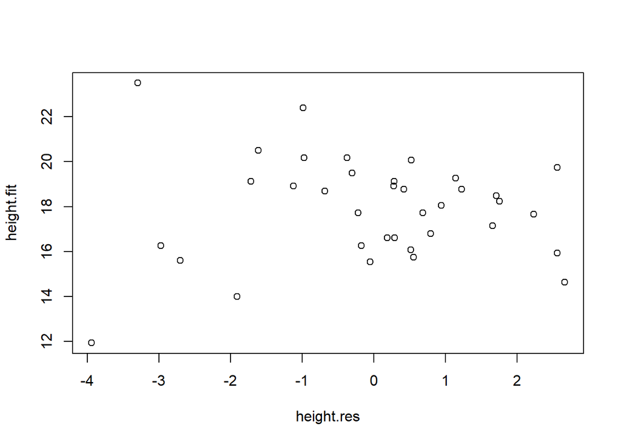

```r
# Now make the linear model
spruce.lm=lm(Height~BHDiameter,data=spruce.df)
#residuals  created from the linear model object
height.res=residuals(spruce.lm)
#fitted values made from the linear model object
height.fit=fitted(spruce.lm)
#Make the plot using the plot function
plot(height.res,height.fit)
```

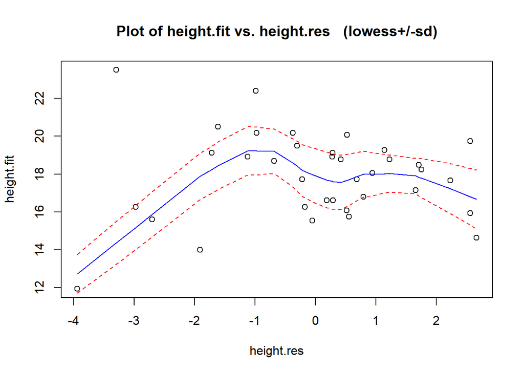

```r
# Put a lowess smoother through res vs fitted
trendscatter( height.res,height.fit)
```

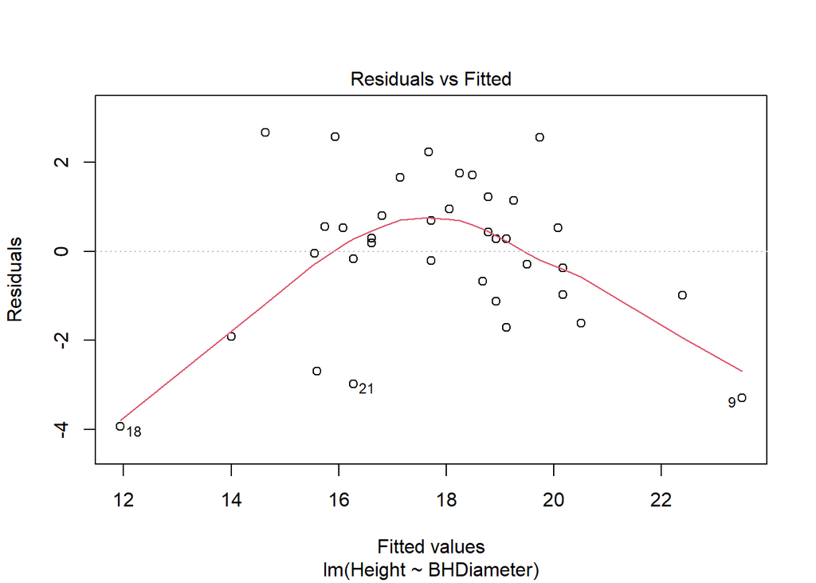

```r
# Quick way to make a residual plot
plot(spruce.lm, which =1)
```

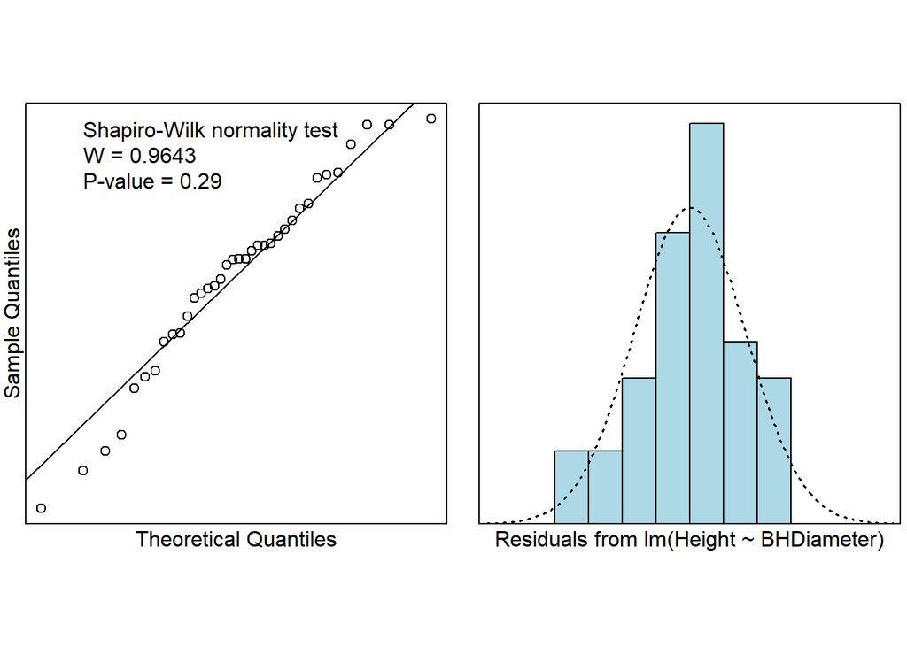

```r
# Checking normality
normcheck(spruce.lm,shapiro.wilk = TRUE)
```

The shape of the curve in residuals vs fitted values using trendscatter() is am imperfect normal distribution in shape. The other curve mentioned looks like something akin to an exponential distribution in shape.

The p-value for the Shapiro-Wilk Test in this case is .29. If the p-value is greater than .05, then the null hypothesis is accepted. This is the case here;i.e., we accept the NULL hypothesis is normally distributed data.

The issue with applying the straight line to this data set is that it doesn’t truly capture the trend of the distribution as well as this current model.